# Comparison Between Soluble Mediator Profiles in COPD and E-Cig Use

Elise Hickman

# 1 Load packages

```r
# Clears global environment
rm(list = ls(all.names = TRUE))

# If needed, install and load packages
library(readxl) # for data import
library(tidyverse) # for data organization
library(janitor) # for data cleaning
library(openxlsx) # for writing out results
library(DT) # for visualizing tables in R markdown
library(vegan) # for Jaccard distance
library (RColorBrewer) # for correlation plot
library(corrplot) # for correlation plot
library(patchwork) # for graphing
library(igraph) # for network figure
library(scales) # for network figure
library(ggpubr) # for making figure panel
library(factoextra) # for PCA
library(forcats) # for releveling
library(rstatix) # for Mahalanobis distance
library(HDMD) # for Mahalanobis distance
library(cluster) # for Mahalanobis distance
library(sva) # for batch adjustment
library(ggpmisc) # for graphing
library(pheatmap) # for heatmaps
library(viridis) # for colors
library(kohonen) # for self-organizing heat map
library(factoextra) # for k-means clustering
library(table1) # for summary table

# Naming function with conflict
select <- dplyr::select

# Set graphing theme
theme_set(theme_bw())
```

# 2 Import and clean data

“md” is used to indicate “mediator data.”

## 2.1 COPD

Data is imported from files that were created as part of the “Summary Tables and Variable by Variable Analysis” code.

```r
# Mediator data
md_copd <- data.frame(read_excel("1_InputFiles/processed_md_data.xlsx"))

# Set variables as factors
md_copd$GoldStage <- factor(md_copd$GoldStage, levels = c("Control", "Pre-COPD", "GOLD 1/2", "GOLD 3"))
```

## 2.2 E-Cig

Import data from Hickman et al 2022 (Biomarkers of Airway Immune Homeostasis Differ Significantly with Generation of E-Cigarettes, DOI: 10.1164/rccm.202202-0373OC). Mediator filtering and imputed was copied from the code from the previous study.

```r
# Import data table
demo_ecig <- read.csv("1_InputFiles/2021_06_15 E-Cig IS Project Demographics.csv")

# Import data table as data frame and make Subject IDs row labels.
md_ecig <- data.frame(read_excel("1_InputFiles/2021_06_29 E-Cig IS Project Mediators.xlsx"))
md_ecig_devices <- data.frame(md_ecig$Device, row.names = md_ecig$Subject_ID)

# Create only numeric data
md_ecig <- data.frame(md_ecig[ , 3:47], row.names = md_ecig$Subject_ID)

# Filter out mediators that were detected in fewer than 25 subjects (~25% of the cohort, since we have four groups).
md_ecig <- md_ecig[, which(as.numeric(colSums(md_ecig != 0)) > 25)]

# Impute zeroes as the sqrt of the lowest value in that column.
md_ecig <- as.data.frame(apply(md_ecig[ , 1:43], 2, function(x) replace(x, x == 0, sqrt(min(x[x>0])))))

# Put column names in alphabetical order
md_ecig <- md_ecig[,order(names(md_ecig))]

# Add groups and demographics back into data frame
demo_ecig$Subject.ID <- sub(" ", "_", demo_ecig$Subject.ID) # Make subject ID formatting match the mediator dataframe

md_ecig <- md_ecig %>%
  rownames_to_column("Subject.ID") %>%
  right_join(demo_ecig, by = "Subject.ID")
```

## 2.3 Merge data frames

Some cleaning steps are needed to match column names of one data frame to the other data frame, clarify group labels, and add batch. Controls from each study were renamed “Control” in the new “Group_2” column rather than their study-specific name (COPD1 for COPD cohort, NS/NV for e-cig study).

```r
md_copd_cleaned <- md_copd %>%
  mutate("Batch" = "COPD") %>%
  rename("Group" = "GoldStage") %>%
  mutate(Group_2 = Group)

md_ecig_cleaned <- md_ecig %>%
  rename("SubjectID" = "Subject.ID") %>%
  rename("Group" = "Device") %>%
  mutate("Batch" = "E-Cig") %>%
  mutate(Group_2 = recode(Group, "NS/NV" = "Control")) %>%
  filter(Group != "SM")
```

Trim data frames to columns found in both data frames.

```r
# COPD
md_copd_cleaned <- data.frame(md_copd_cleaned[, colnames(md_copd_cleaned) %in% colnames(md_ecig_cleaned)])

# E-Cig
md_ecig_cleaned <- data.frame(md_ecig_cleaned[, colnames(md_ecig_cleaned) %in% colnames(md_copd_cleaned)])
```

Merge the two data frames and recode demographic variables so they match. Subject IDs are put back into row names since that is where they will need to be for the next steps.

```r
md_all <- bind_rows(md_copd_cleaned, md_ecig_cleaned) %>%
  column_to_rownames("SubjectID")
```

# 3 Outlier detection

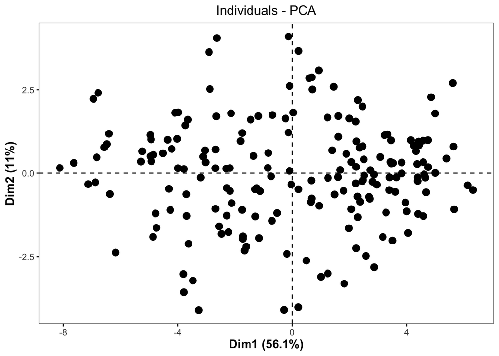

```r
# Prepare data frame for PCA
pseudolog <- function(x) log2(x+1)

pca_df <- md_all %>%
  dplyr::select(CRP:VEGF) %>%
  mutate(across(where(is.numeric), pseudolog))

# Run PCA
pca <- prcomp(pca_df, scale = TRUE)

# Visualize PCA to see if any obvious outliers are detected
fviz_pca_ind(pca,
             label = "none",
             pointsize = 3) +
theme(axis.title = element_text(face = "bold", size = rel(1.1)),
      panel.border = element_rect(fill = NA, color = "black", linewidth = 0.3),
      panel.grid.minor = element_blank(),
      panel.grid.major = element_blank(),
      plot.title = element_text(hjust = 0.5))
```

By visual inspection, there aren’t any obvious outliers, so we can use a formula to detect outliers. One standard way to detect outliers is the criterion of being “more than 6 standard deviations away from the mean.” [Source](https://privefl.github.io/blog/detecting-outlier-samples-in-pca/)

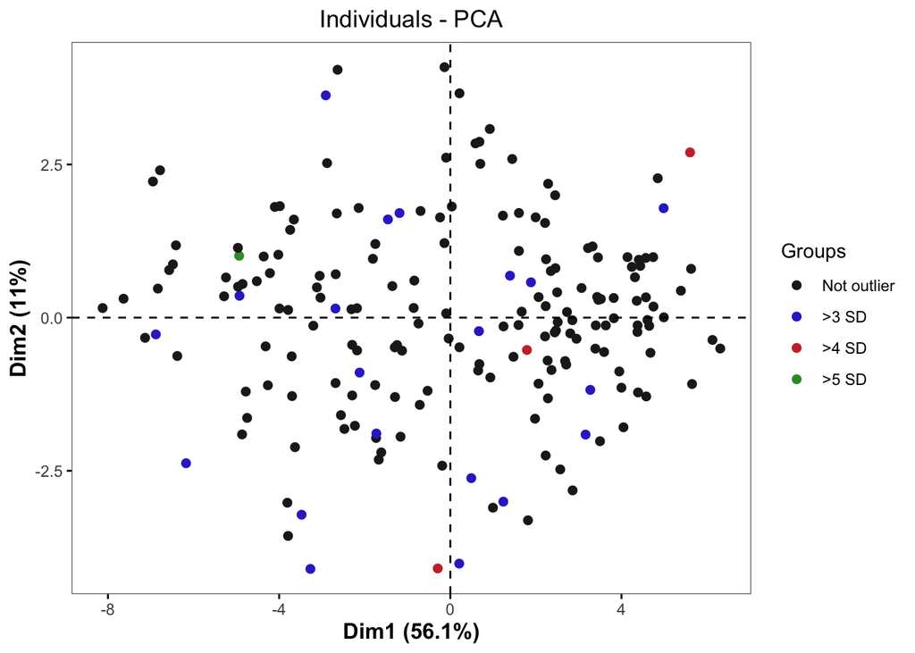

```r
# Create a scoring funciton to detect PCA sample outliers. The input is PCA results data frame and the number of standard deviations for the cutoff. The output is outlier names.
outlier_detection = function(pca_df, sd){

    # getting scores
    scores = pca_df$x

    # identifying samples that are > 6 standard deviations away from the mean
    outlier_indices = apply(scores, 2, function(x) which( abs(x - mean(x)) > (sd * sd(x)) )) %>%
        Reduce(union, .)

    # getting sample names
    outliers = rownames(scores)[outlier_indices]

    return(outliers)
}

# Call function with different standard deviation cutoffs
outliers_6 <- outlier_detection(pca, 6)
outliers_5 <- outlier_detection(pca, 5)
outliers_4 <- outlier_detection(pca, 4)
outliers_3 <- outlier_detection(pca, 3)

# Summary data frame
outlier_summary <- data.frame(sd_cutoff = c(6, 5, 4, 3), n_outliers = c(length(outliers_6), length(outliers_5), length(outliers_4), length(outliers_3)))

# Make subject lists for different cutoffs
outliers_5_only <- outliers_5
outliers_4_only <- outliers_4[!outliers_4 %in% outliers_5_only]
outliers_3_only <- outliers_3[!outliers_3 %in% outliers_4]

# Add a column coding for subject removal/outlier identification based on SD cutoff
md_all_pca <- md_all %>%
  rownames_to_column("SubjectID") %>%
  mutate("Outlier Cutoff" = ifelse(SubjectID %in% outliers_5_only, ">5 SD",
                                   ifelse(SubjectID %in% outliers_4_only, ">4 SD",
                                          ifelse(SubjectID %in% outliers_3_only, ">3 SD", "Not outlier")))) %>%
  column_to_rownames("SubjectID") %>%
  mutate(`Outlier Cutoff` = fct_relevel(`Outlier Cutoff`, c ("Not outlier", ">3 SD", ">4 SD", ">5 SD")))

# Graph PCA with outliers
PCA_outliers_plot <- fviz_pca_ind(pca,
             label = "none",
             habillage = md_all_pca$`Outlier Cutoff`,
             palette = c("gray12", "#3333CC", "#CC3333", "#339933"),
             mean.point = FALSE,
             pointsize = 3) +
  scale_shape_manual(values = c(20, 20, 20, 20)) +
theme(axis.title = element_text(face = "bold", size = rel(1.1)),
      panel.border = element_rect(fill = NA, color = "black", size = 0.3),
      panel.grid.minor = element_blank(),
      panel.grid.major = element_blank(),
      plot.title = element_text(hjust = 0.5))
PCA_outliers_plot
```

```r
#pdf(file = "2_OutputFigs/MergedData_PCAOutliers.pdf",
    #width = 8,
    #height = 5)

#PCA_outliers_plot

#invisible(dev.off())
```

# 4 Correlation plots

## 4.1 Make correlation plots

```r
# Filter data frame for each group of interest
ec_ctrl <- filter(md_ecig_cleaned, Group == "NS/NV")
ec_3rdgen <- filter(md_ecig_cleaned, Group == "3rd Gen")
ec_4thgen <- filter(md_ecig_cleaned, Group == "4th Gen")
copd_ctrl <- filter(md_copd_cleaned, Group == "Control")
copd_p <- filter(md_copd_cleaned, Group == "Pre-COPD")
copd_1.2 <- filter(md_copd_cleaned, Group == "GOLD 1/2")
copd_3 <- filter(md_copd_cleaned, Group == "GOLD 3")

# To add significance to correlation plot, run this function
cor.mtest <- function(mat, ...) {
  mat <- as.matrix(mat)
  n <- ncol(mat)
  p.mat<- matrix(NA, n, n)
  diag(p.mat) <- 0
  for (i in 1:(n - 1)) {
    for (j in (i + 1):n) {
      tmp <- cor.test(mat[, i], mat[, j], ...)
      p.mat[i, j] <- p.mat[j, i] <- tmp$p.value
    }
  }
  colnames(p.mat) <- rownames(p.mat) <- colnames(mat)
  p.mat
}

# Make a data frame with plot titles for each plot
corrplot_titles <- data.frame(data_frame_name = c("ec_ctrl", "ec_3rdgen", "ec_4thgen", "copd_ctrl", "copd_p", "copd_1.2", "copd_3"),
                              plot_title = c("E-Cig Study Controls", "3rd Gen E-Cig Users", "4th Gen E-Cig Users", "COPD Study Controls", "Pre-COPD", "GOLD Stage 1/2", "GOLD Stage 3"))

# Function for making correlation plot

custom.corrplot <- function(data, corrplot_titles) {

  df_name <- deparse(substitute(data))

  plot_title <- (corrplot_titles %>% filter(data_frame_name == df_name))[1,2]

  data_dm <- data %>%
    column_to_rownames("SubjectID") %>%
    dplyr::select(CRP:VEGF) %>%
    data.matrix()

  data_corr <- cor(data_dm)
  data_corr[data_corr <= 0.6 & data_corr >= -0.6] = 0 # Show only correlations with |R| > 0.6

  p.mat <- cor.mtest(data_dm)

  corrplot(data_corr,
           method = "circle",
           type = "upper",
           order = "alphabet",
           tl.col = "black",
           p.mat = p.mat,
           sig.level = 0.01,
           insig = "blank",
           diag = FALSE,
           title = plot_title,
           mar=c(0,0,1,0),
           tl.cex = 0.7)

}

# Make panel of correlation plots and write them out
pdf(file = "2_OutputFigs/Corrplots.pdf",   # The directory you want to save the file in
    width = 6, # The width of the plot in inches
    height = 12)

par(mfrow = c(4, 2))
corrplot_ctrl <- custom.corrplot(copd_ctrl, corrplot_titles)
corrplot_p <- custom.corrplot(copd_p, corrplot_titles)
corrplot_1.2 <- custom.corrplot(copd_1.2, corrplot_titles)
corrplot_3 <- custom.corrplot(copd_3, corrplot_titles)
corrplot_ns <- custom.corrplot(ec_ctrl, corrplot_titles)
corrplot_3rdgen <- custom.corrplot(ec_3rdgen, corrplot_titles)
corrplot_4thgen <- custom.corrplot(ec_4thgen, corrplot_titles)

dev.off()
```

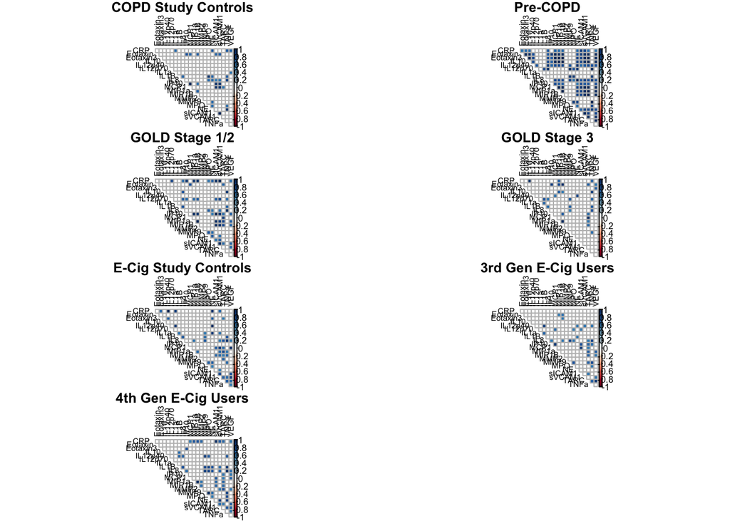

```r
par(mfrow = c(4, 2))
corrplot_ctrl <- custom.corrplot(copd_ctrl, corrplot_titles)
corrplot_p <- custom.corrplot(copd_p, corrplot_titles)
corrplot_1.2 <- custom.corrplot(copd_1.2, corrplot_titles)
corrplot_3 <- custom.corrplot(copd_3, corrplot_titles)
corrplot_ns <- custom.corrplot(ec_ctrl, corrplot_titles)
corrplot_3rdgen <- custom.corrplot(ec_3rdgen, corrplot_titles)
corrplot_4thgen <- custom.corrplot(ec_4thgen, corrplot_titles)
```

## 4.2 Quantify the similarities in correlation matrices between groups

The purpose for this section of code is to count how many similar correlations there are between correlation matrices of each group. This is completed by first counting the number of significant comparisons (defined as |R| > 0.6 and p < 0.01) that are the same between each matrix (in a pairwise approach). Then, that number is subtracted from the total number of comparisons to get the number of non-significant comparisons. Last, the results are tabulated together and a total similarity count is determined.

First, we need to take the results of the correlation functions used to generate the plots above and reorganize them into a useful format for comparing the results.

```r
# Function to create summary table of correlation values using separate data frames for each group
corr_pval_summary_sig <- function(data) {

  # make numeric data matrix
  data_dm <- data %>%
    column_to_rownames("SubjectID") %>%
    dplyr::select(CRP:VEGF) %>%
    data.matrix()

  data_corr <- cor(data_dm) # calculate correlations
  p.mat <- cor.mtest(data_dm) # calculate p values for correlations

  # Summarize correlation values by creating a new data frame containing each variable in the pair in its own column as well as a column that combines those two variables. "upper tri" takes the upper half of the correlation matrix since as a square matrix, there are duplicate values for each pair.
  corrsummary <- data.frame(var1 = rownames(data_corr)[row(data_corr)[upper.tri(data_corr)]],
           var2 = colnames(data_corr)[col(data_corr)[upper.tri(data_corr)]],
           corr = data_corr[upper.tri(data_corr)]) %>%
  unite(var1_var2, var1, var2, sep = "_", remove = TRUE)

  # Summarizes p values using the same mechanics as in summarizing correlation values above
  psummary <- data.frame(var1 = rownames(p.mat)[row(p.mat)[upper.tri(p.mat)]],
           var2 = colnames(p.mat)[col(p.mat)[upper.tri(p.mat)]],
           pval = p.mat[upper.tri(p.mat)]) %>%
  unite(var1_var2, var1, var2, sep = "_", remove = TRUE)

  # Create a variable representing the name of the input data
  df_name = paste0(deparse(substitute(data)))

  # Join together correlation coefficients and pvalues; filter by magnitude of correlation and significance of correlation, and add a column to indicate what group these correlations are coming from
  corrpval <- right_join(corrsummary, psummary, by = "var1_var2") %>%
  filter(abs(corr) > 0.6 & pval < 0.01) %>%
  mutate("group" = df_name)

  # Return final data frame
  corrpval
}

# Apply to each of the data frames we are interested in
corrpval_copdctrl_sig <- corr_pval_summary_sig(copd_ctrl)
corrpval_copdp_sig <- corr_pval_summary_sig(copd_p)
corrpval_copd1.2_sig <- corr_pval_summary_sig(copd_1.2)
corrpval_copd3_sig <- corr_pval_summary_sig(copd_3)
corrpval_ecctrl_sig <- corr_pval_summary_sig(ec_ctrl)
corrpval_ec3rdgen_sig <- corr_pval_summary_sig(ec_3rdgen)
corrpval_ec4thgen_sig <- corr_pval_summary_sig(ec_4thgen)

datatable(corrpval_copdctrl_sig)
```

|  | var1_var2 | corr | pval | group |
| --- | --- | --- | --- | --- |
| 1 | CRP_IL1a | 0.6609177959865496 | 0.0003224857342515035 | copd_ctrl |
| 2 | IL1B_IL8 | 0.6935425025445064 | 0.0001209278534063557 | copd_ctrl |
| 3 | Eotaxin_IP10 | 0.7987265208711247 | 1.699072341083772e-06 | copd_ctrl |
| 4 | Eotaxin_MCP1 | 0.6909017869099405 | 0.0001315249075665291 | copd_ctrl |
| 5 | IP10_MCP1 | 0.9702937319494175 | 1.130418354315569e-15 | copd_ctrl |
| 6 | Eotaxin_MIP1B | 0.7357864868856374 | 2.77063648066963e-05 | copd_ctrl |
| 7 | IP10_MIP1B | 0.667737241417555 | 0.0002652852763095036 | copd_ctrl |
| 8 | MIP1a_MIP1B | 0.7221424499325945 | 4.588873333266833e-05 | copd_ctrl |
| 9 | IL1B_MPO | 0.9020099138221433 | 7.358476256737478e-10 | copd_ctrl |
| 10 | IL8_MPO | 0.6632971517507085 | 0.0003014143552552916 | copd_ctrl |

[output cut: 22 more lines]

Next, we need to create a data frame of all possible correlations, with correlations in rows and groups in columns. 1 will indicate that this correlation was significant and with |R| > 0.6, while 0 will indicate absence of that relationship in that group. This input will be passed to Jaccard distnace/similarity metric

```r
# We can extract the pairs of variables using similar code to the start of our function above

# Make numeric data matrix
data_dm <- ec_ctrl %>%
  column_to_rownames("SubjectID") %>%
  dplyr::select(CRP:VEGF) %>%
  data.matrix()

# Calculate correlations
data_corr <- cor(data_dm)

# Create data frame
corrsummary_counts <- data.frame(var1 = rownames(data_corr)[row(data_corr)[upper.tri(data_corr)]],
           var2 = colnames(data_corr)[col(data_corr)[upper.tri(data_corr)]]) %>%
  unite(var1_var2, var1, var2, sep = "_", remove = TRUE)

# 231 total correlations possible
length(corrsummary_counts$var1_var2)
```

```
## [1] 231
```

```r
# Clean data frames
corrpval_copdctrl_sig_cl <- corrpval_copdctrl_sig %>% mutate(group = 1) %>% rename("copd_ctrl" = "group") %>%  select(-c(corr, pval))
corrpval_copdp_sig_cl <- corrpval_copdp_sig %>% mutate(group = 1) %>% rename("copd_p" = "group") %>%  select(-c(corr, pval))
corrpval_copd1.2_sig_cl <- corrpval_copd1.2_sig %>% mutate(group = 1) %>% rename("copd_1.2" = "group") %>%  select(-c(corr, pval))
corrpval_copd3_sig_cl <- corrpval_copd3_sig %>% mutate(group = 1) %>% rename("copd_3" = "group") %>%  select(-c(corr, pval))
corrpval_ecctrl_sig_cl <- corrpval_ecctrl_sig %>% mutate(group = 1) %>% rename("ec_ctrl" = "group") %>%  select(-c(corr, pval))
corrpval_ec3rdgen_sig_cl <- corrpval_ec3rdgen_sig %>% mutate(group = 1) %>% rename("ec_3rdgen" = "group") %>%  select(-c(corr, pval))
corrpval_ec4thgen_sig_cl <- corrpval_ec4thgen_sig %>% mutate(group = 1) %>% rename("ec_4thgen" = "group") %>%  select(-c(corr, pval))

# Add binary data to data frame indicating if that group contained that correlations
all_dfs <- list(corrpval_copdctrl_sig_cl, corrpval_copdp_sig_cl, corrpval_copd1.2_sig_cl, corrpval_copd3_sig_cl, corrpval_ecctrl_sig_cl, corrpval_ec3rdgen_sig_cl, corrpval_ec4thgen_sig_cl)

# Create binary data frame for Jaccard distance
df_counts <- all_dfs %>%
  reduce(full_join, by = "var1_var2") %>%
  column_to_rownames("var1_var2") %>%
  replace(is.na(.), 0)
```

Next, calculate Jaccard similarity/distance metric. Raw output indicates dissimilarity, in that the closer the number is to 1, the more dissimilar the groups are. We will reverse this later.

```r
jd <- as.data.frame(as.matrix(vegdist(t(df_counts), method = "jaccard")))
```

## 4.3 Vizualizing similarities in correlation matrices between groups

### 4.3.1 visNetwork

Create needed data frames for input:

```r
# Process jaccard data frame so that the format is passable to visNetwork
corrcount_network_edges <- data.frame(from = rownames(jd)[row(jd)[upper.tri(jd)]],
           to = colnames(jd)[col(jd)[upper.tri(jd)]],
           weight = jd[upper.tri(jd)]) %>%
  mutate(from = recode(from, "copd_ctrl" = "1", "copd_p" = "2", "copd_1.2" = "3", "copd_3" = "4", "ec_ctrl" = "5", "ec_3rdgen" = "6", "ec_4thgen" = "7")) %>%
  mutate(to = recode(to, "copd_ctrl" = "1", "copd_p" = "2", "copd_1.2" = "3", "copd_3" = "4", "ec_ctrl" = "5", "ec_3rdgen" = "6", "ec_4thgen" = "7")) %>%
  mutate(weight = 1 - weight) # Vegan provides Jaccard dissimilarity, while we need similarity to be the weight

# Define nodes by creating a data frame describing the groups
corrcount_network_nodes <- data.frame(id = 1:7, # id column must be called "id"
                                      group = c("COPD Ctrl", "Pre-COPD", "GOLD 1/2", "GOLD 3",
                                                "EC Ctrl", "EC 3rd Gen", "EC 4th Gen"),
                                      study = c("COPD", "COPD", "COPD", "COPD", "Ecig", "Ecig", "Ecig"),
                                      subject_type = c("Control", "COPD", "COPD", "COPD", "Control", "Ecig", "Ecig")) %>%
  mutate(color = recode(subject_type, "Control" = "1", "Ecig" = "2", "COPD" = "3")) %>%
  mutate(color = as.numeric(color))
```

Add customization elements:

```r
# Add customization to node visualization
network_colors <- c("#FDE725", "#5EC962", "#FE9F6D")

corrcount_network_nodes <- corrcount_network_nodes %>%
  mutate(label = group,
         color = network_colors[color],
         color.border = "black")

# Add customization to edge visualization
edge_palette <- colorRampPalette(c("#08519c", "#6baed6","#deebf7"))
edge_colors <- rev(edge_palette(21))

corrcount_network_edges <- corrcount_network_edges %>%
  mutate(weight_scaled = scales::rescale(weight, to = c(0.1, 1))) %>%
  mutate(width = weight_scaled*10,
         smooth = TRUE) %>%
  arrange(width) %>% # the network will plot the first row in the data frame first, and I want the highest values to be on top
  mutate(color = edge_colors)
```

Create network visualization:

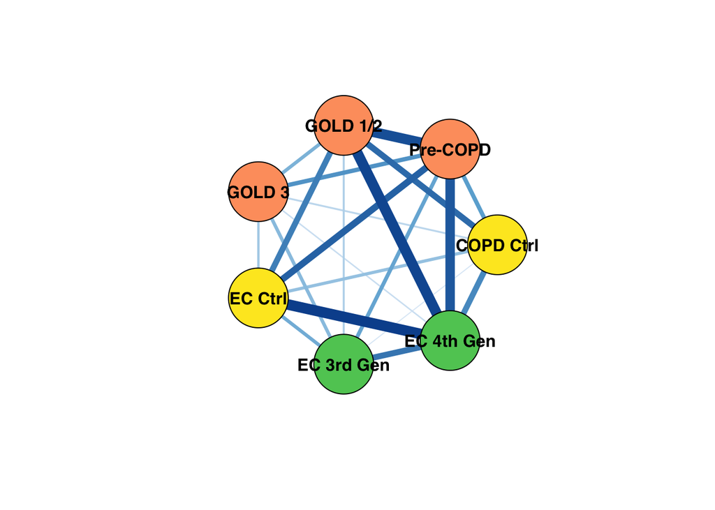

```r
# Create graphing object.
net <- graph.data.frame(corrcount_network_edges, corrcount_network_nodes, directed = F)

plot(net,
     vertex.label.family = "sans",
     vertex.label.font = 2,
     vertex.color = V(net)$color,
     vertex.label.color = "black",
     arrow.mode = c("0"),
     vertex.size = 50,
     edge.color = E(net)$color,
     layout = layout.circle(net))
```

```r
# Output file
pdf(file = "2_OutputFigs/CorrelationJaccardNetwork.pdf",   # The directory you want to save the file in
    width = 4, # The width of the plot in inches
    height = 4)

plot(net,
     vertex.label.family = "sans",
     vertex.label.font = 2,
     vertex.label.cex = 0.8,
     vertex.color = V(net)$color,
     vertex.label.color = "black",
     arrow.mode = c("0"),
     vertex.size = 50,
     edge.color = E(net)$color,
     layout = layout.circle(net))

invisible(dev.off())
```

We also need to make a legend for the network plot.

```r
# Use this code to visualize palette with a vertical legend
legend_df <- corrcount_network_edges %>% rownames_to_column("legend") %>% mutate(across(legend, as.numeric)) %>% mutate(weight = round(weight, 2))

vertical_legend <- ggplot(legend_df, aes(x = legend, y = 1)) +
  geom_bar(aes(fill = color), stat = "identity", width = 1) +
  coord_flip() +
  scale_fill_manual(values = rev(legend_df$color)) +
  geom_text(data = legend_df %>% slice(1, nrow(legend_df)),
            aes(x = legend, y = 1, label = weight), hjust = 0, size = 12, nudge_y = 0.2) +
  xlim(c(-1, 22)) +
  ylim(c(-0.5, 2.5)) +
  theme(legend.position = "none",
        axis.text = element_blank(),
        axis.title = element_blank(),
        axis.ticks = element_blank(),
        panel.grid = element_blank(),
        panel.border = element_blank())

pdf(file = "2_OutputFigs/NetworkLegend.pdf",
    width = 3,
    height = 5.5)

vertical_legend

dev.off()
```

Writing out of Jaccard similarity results for supplemental table.

```r
jaccard_results <- corrcount_network_edges %>%
  select(c(from, to, weight)) %>%
  left_join(corrcount_network_nodes %>% rename("from" = "id") %>% mutate(from = as.character(from)) %>% select(c(from, group)), by = "from") %>%
  select(-from) %>%
  rename("from" = "group") %>%
  left_join(corrcount_network_nodes %>% rename("to" = "id") %>% mutate(to = as.character(to)) %>% select(c(to, group)), by = "to") %>%
  select(-to) %>%
  rename("to" = "group") %>%
  relocate(weight, .after = to) %>%
  arrange(-weight) %>%
  rename("Group 1" = "from", "Group 2" = "to", "Jaccard Similarity" = "weight")

write.xlsx(jaccard_results, "3_OutputTables/Jaccard_ForSupplement.xlsx")
```

# 5 Removing batch effects with ComBat

## 5.1 Obtain batch-adjusted values

The code in this section was modeled after the vignettes shown in the [SVA package documentation](https://www.bioconductor.org/packages/devel/bioc/vignettes/sva/inst/doc/sva.pdf).

```r
# Read in COPD Demographics
demo_copd <- read.xlsx("1_InputFiles/2023_06_09 COPD Demographics.xlsx") %>%
  select(c("SubjectID", "Age"))

demo_combo <- rbind(demo_copd, demo_ecig %>% rename("SubjectID" = "Subject.ID") %>% dplyr::select(c("SubjectID", "Age")))

# Create data frame of subject groups and ages.
demo_all <- md_all %>%
  rownames_to_column("SubjectID") %>%
  left_join(demo_combo, by = "SubjectID") %>%
  dplyr::select(c("SubjectID", "Age", "Group", "Group_2", "Batch"))

# Create data frame of only mediator expression data
md_all_trans <- md_all %>%
  dplyr::select(CRP:VEGF) %>%
  t() %>%
  as.data.frame()
```

Creating matrix model. An explanation of the par.prior and prior.plot arguments can be found [here] (https://support.bioconductor.org/p/71198/). Based on recommendations there and prior plots below, we will keep par.prior = TRUE.

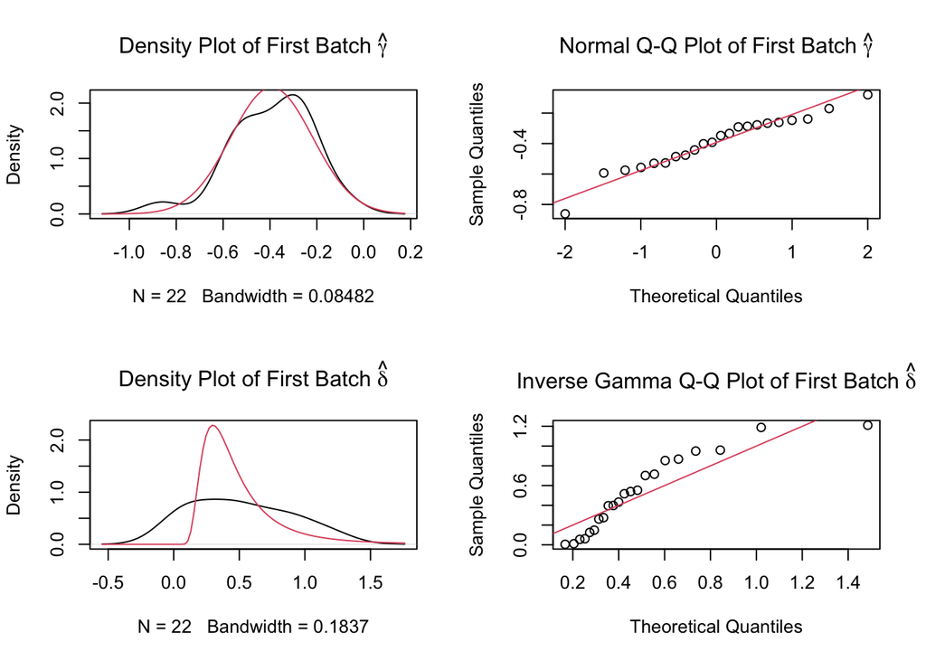

```r
# Create batch vector
batch = demo_all$Batch

# Create model matrix
modcombat = model.matrix(~ Group_2, data = demo_all)

# First run the adjustment with prior.plot = TRUE to see if estimate of the empirical batch effect density (black) matches a parametric estimate (red). Guidance for the ComBat function indicates very minimal difference between par.prior = TRUE and FALSE.
set.seed(118) # Not sure if this is necessary, but doing it just in case
combat_md <- ComBat(dat = md_all_trans, batch = batch, mod = modcombat, par.prior = TRUE, prior.plot = TRUE)
```

Visualizing adjusted values.

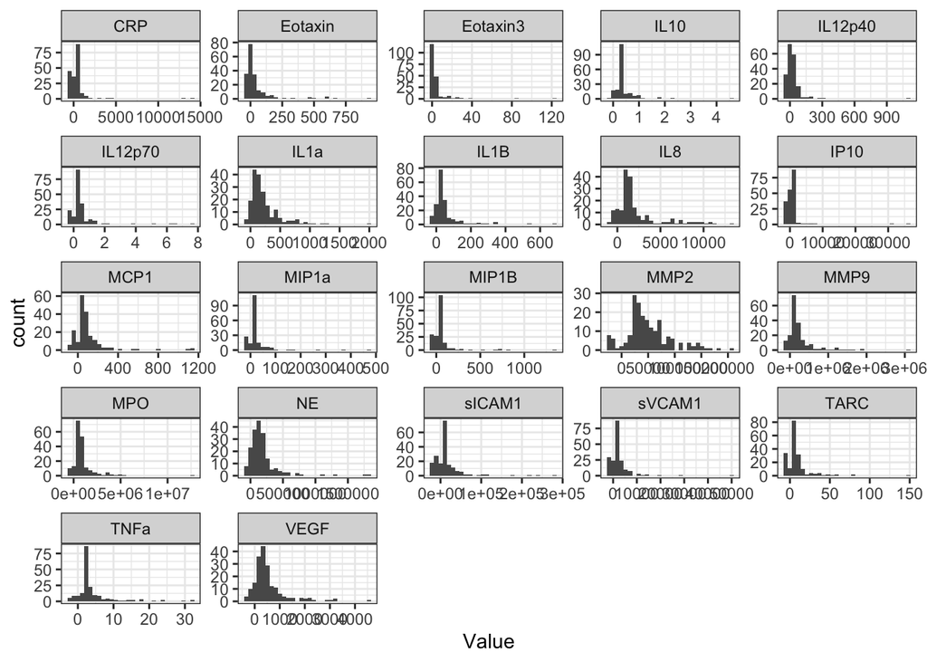

```r
histograms <- combat_md %>%
  t() %>%
  as.data.frame() %>%
  pivot_longer(CRP:VEGF,
               names_to = "Variable",
               values_to = "Value") %>%
  ggplot(aes(Value)) +
  geom_histogram() +
  facet_wrap(~ Variable, scales = "free")

histograms
```

Counting positive and negative values demonstrates that a number of values are now negative, but because our primary interest is in relative measures, not absolute concentrations, this is okay.

```r
posneg_counts <- combat_md %>%
  t() %>%
  as.data.frame() %>%
  pivot_longer(CRP:VEGF,
               names_to = "Variable",
               values_to = "Value") %>%
  group_by(Variable) %>%
  mutate(positive = sum(Value > 0), negative = sum(Value < 0)) %>%
  distinct(Variable, .keep_all = TRUE) %>%
  select(-Value)

datatable(posneg_counts)
```

|  | Variable | positive | negative |
| --- | --- | --- | --- |
| 1 | CRP | 129 | 62 |
| 2 | Eotaxin | 102 | 89 |
| 3 | Eotaxin3 | 158 | 33 |
| 4 | IL10 | 172 | 19 |
| 5 | IL12p40 | 125 | 66 |
| 6 | IL12p70 | 160 | 31 |
| 7 | IL1a | 180 | 11 |
| 8 | IL1B | 166 | 25 |
| 9 | IL8 | 168 | 23 |
| 10 | IP10 | 126 | 65 |

[output cut: 12 more lines]

## 5.2 Compare data before and after adjustment

Pre ComBat adjustment data.

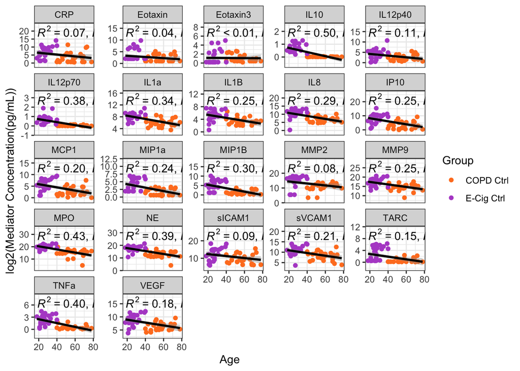

```r
# Filter and organize data
age_corr_data_pre <- filter(md_all, Group == "NS/NV" |  Group == "Control") %>%
  rownames_to_column("SubjectID") %>%
  left_join(demo_combo, by = "SubjectID") %>%
  mutate(Group = recode(Group, "Control" = "COPD Ctrl", "NS/NV" = "E-Cig Ctrl"))

pseudolog <- function(x) log2(x+1)

age_corr_data_pre_forscatterplot <- age_corr_data_pre %>%
  pivot_longer(CRP:VEGF,
               names_to = "Variable",
               values_to = "Value") %>%
  mutate(Value_Log = pseudolog(Value))

# Make plot
age_corr_pre_facetgraph <- ggplot(age_corr_data_pre_forscatterplot, aes(x = Age, y = Value_Log)) +
  geom_point(aes(color = Group)) +
  scale_color_manual(values = c("chocolate1", "mediumorchid3")) +
  stat_poly_line(color = "black") +
  stat_poly_eq(use_label(c("R2", "p"))) +
  ylab("log2(Mediator Concentration(pg/mL))") +
  scale_y_continuous(expand = expansion(mult = c(0.25, 0.8))) +
  facet_wrap(~Variable, scales = "free_y")

age_corr_pre_facetgraph
```

```r
#pdf(file = "Output_Files/Age_Correlation_Facetplot_PreAdj.pdf",   # The directory you want to save the file in
    #width = 12, # The width of the plot in inches
    #height = 6)

#age_corr_pre_facetgraph

#dev.off()
```

Post ComBat adjustment data.

```r
# The lowest value of our data is -400547.8, so we will have to add a very large pseudocount to be able to log-transform the data
min(combat_md)
```

```
## [1] -400547.8
```

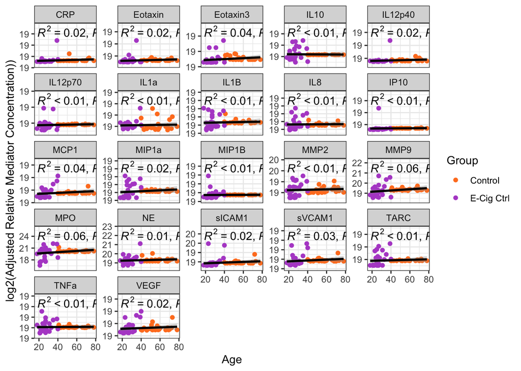

```r
# Create pseudolog function
pseudolog_postadj <- function(x) log2(x+500000)

# Add back in relevant group data to the ComBat-adjusted values
md_combat <- combat_md %>%
  t() %>%
  as.data.frame() %>%
  rownames_to_column("SubjectID")

md_combat_filtered <- md_combat %>%
  right_join(demo_all, by = "SubjectID") %>%
  filter(Group == "NS/NV" |  Group == "Control") %>%
  mutate(Group = recode(Group, "COPD1" = "COPD Ctrl", "NS/NV" = "E-Cig Ctrl"))

age_corr_data_combat_forscatterplot <- md_combat_filtered %>%
  pivot_longer(CRP:VEGF,
               names_to = "Variable",
               values_to = "Value") %>%
  mutate(Value_Log = pseudolog_postadj(Value))

# Make plot
age_corr_post_facetgraph <- ggplot(age_corr_data_combat_forscatterplot, aes(x = Age, y = Value_Log)) +
  geom_point(aes(color = Group)) +
  scale_color_manual(values = c("chocolate1", "mediumorchid3")) +
  stat_poly_line(color = "black") +
  stat_poly_eq(use_label(c("R2", "p"))) +
  ylab("log2(Adjusted Relative Mediator Concentration))") +
  scale_y_continuous(expand = expansion(mult = c(0.25, 0.8)),
                     labels = scales::label_number(accuracy = 1)) +
  facet_wrap(~Variable, scales = "free_y")

age_corr_post_facetgraph
```

```r
#pdf(file = "Output_Files/Age_Correlation_Facetplot_PostComBatAdj.pdf",   # The directory you want to save the file in
    #width = 12, # The width of the plot in inches
   #height = 6)

#age_corr_post_facetgraph

#dev.off()
```

# 6 Heatmaps to explore the relationship between group and relative soluble mediator levels

## 6.1 All groups together

Averaged heatmap of log transformed values with controls grouped together.

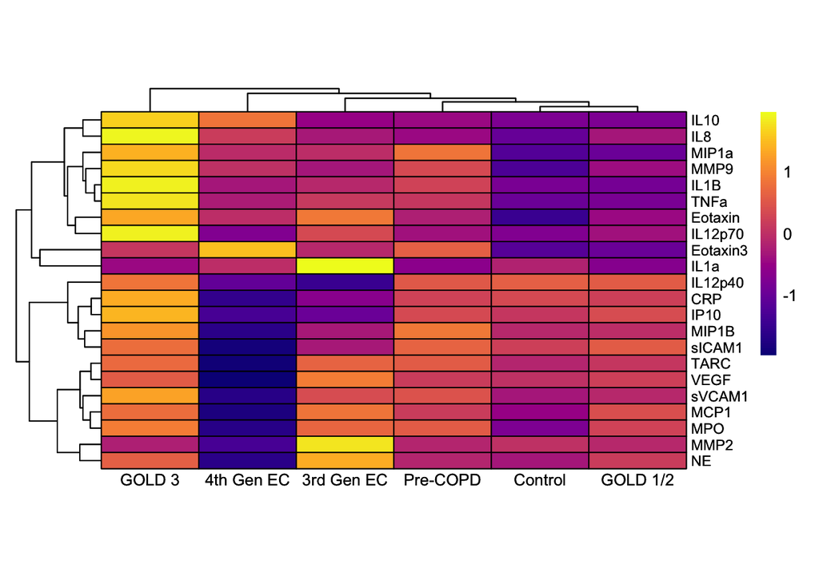

```r
# Make summary data frame
md_combat_heatmap_log_avg_group2 <- md_combat %>%
  mutate(across(where(is.numeric), pseudolog_postadj)) %>%
  right_join(demo_all %>% select(SubjectID, Group_2), by = "SubjectID") %>%
  group_by(Group_2) %>%
  summarize(across(where(is.numeric), mean)) %>%
  mutate(Group_2 = recode(Group_2, "4th Gen" = "4th Gen EC", "3rd Gen" = "3rd Gen EC")) %>%
  column_to_rownames("Group_2")

# Make data matrix
md_combat_heatmap_log_avg_group2_dm <- data.matrix(md_combat_heatmap_log_avg_group2)

# Make heatmap
heatmap <- pheatmap(t(md_combat_heatmap_log_avg_group2_dm ),
         color = plasma(100), # sets color scheme
         angle_col = c("0"), # makes column labels horizontal
         cellwidth = 60, # sets dimensions of cells so that they don't change with viewer pane size
         cellheight = 10, # sets dimensions of cells so that they don't change with viewer pane size
         border_color = "black", # adds black border around cells
         treeheight_col = 10, # sets dims of trees so that they don't change with viewer pane size
         fontsize_row = 9, # sets dims of trees so that they don't change with viewer pane size
         scale = 'row', # scales data by row
         fontsize_col = 10) # sets font size for column labels
heatmap
```

```r
pdf(file = "2_OutputFigs/ECigCOPDHeatmap_BatchAdj_Log_CtrlsTogether_Avg.pdf",
    width = 11,
    height = 6)
heatmap
invisible(dev.off())
```

## 6.2 Separated by biological subsets of mediators

```r
# Neil-defined subsets
immuno_inflamm <- c("IL1a", "IL1B", "IL8", "TNFa", "IL10", "IL12p70", "CRP")
chemotax <- c("Eotaxin", "Eotaxin3", "IL12p40", "IP10", "MCP1", "MIP1a", "MIP1B", "TARC", "sICAM1", "sVCAM1")
prot_enzyme <- c("MMP2", "MMP9", "MPO", "NE")
```

### 6.2.1 Combined controls

```r
# This function takes input of md_combat, variables to keep in the data frame, and desired output dimensions of the heatmap. Output is a saved heatmap in file directory of choice and visualized heatmap in R Markdown.
bygroup_heatmap_ctrls_together <- function (data, variables, width, height, suffix) {

  # Get name of vector
  vector_name <- deparse(substitute(variables))

  # Create heatmap input
  heatmap_input <- data %>%
    mutate(across(where(is.numeric), pseudolog_postadj)) %>%
    right_join(demo_all %>% select(SubjectID, Group_2), by = "SubjectID") %>%
    group_by(Group_2) %>%
    summarize(across(where(is.numeric), mean)) %>%
    mutate(Group_2 = recode(Group_2, "4th Gen" = "4th Gen EC", "3rd Gen" = "3rd Gen EC")) %>%
    column_to_rownames("Group_2") %>%
    select(all_of(variables)) %>%
    data.matrix()

  # Make heatmap
  heatmap <- pheatmap(t(heatmap_input),
         color = plasma(100), # sets color scheme
         angle_col = c("0"), # makes column labels horizontal
         cellwidth = 60, # sets dimensions of cells so that they don't change with viewer pane size
         cellheight = 10, # sets dimensions of cells so that they don't change with viewer pane size
         border_color = "black", # adds black border around cells
         treeheight_col = 10, # sets dims of trees so that they don't change with viewer pane size
         fontsize_row = 9, # sets dims of trees so that they don't change with viewer pane size
         scale = 'row', # scales data by row
         fontsize_col = 10) # sets font size for column labels


  # Write out PDF
  dev.off()

  pdf(file = paste0("2_OutputFigs/Heatmap_ByBioSet_CtrlsTogether_Avg_",
                    vector_name, suffix, ".pdf"),
    width = width,
    height = height)

  print(heatmap)

  dev.off()

  # Return heatmap
  heatmap
}

# Create heatmaps - batch corrected
bygroup_heatmap_ctrls_together(md_combat, immuno_inflamm, 8, 4, "_BatchAdj")
bygroup_heatmap_ctrls_together(md_combat, chemotax, 8, 4, "_BatchAdj")
bygroup_heatmap_ctrls_together(md_combat, prot_enzyme, 8, 4, "_BatchAdj")
```

### 6.2.2 Individual subjects

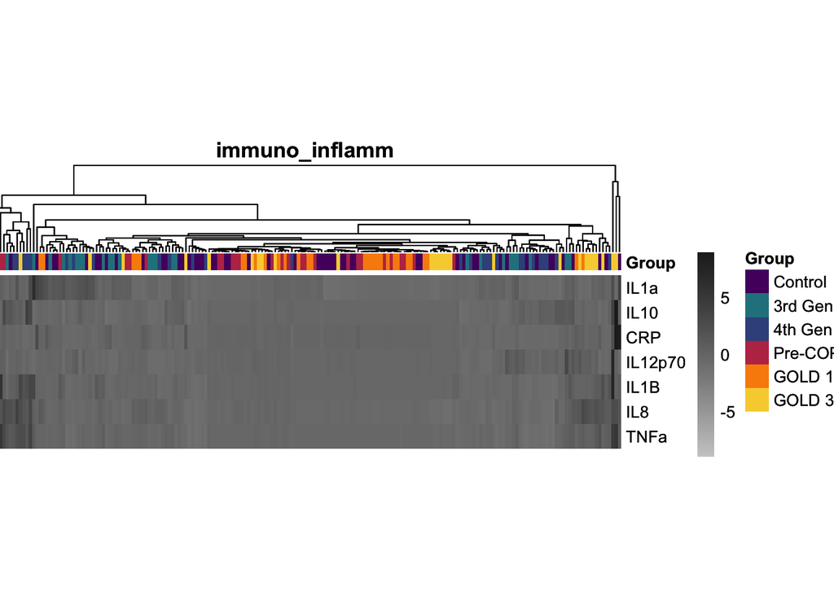

```r
# Make color palette
indiv_hm_palette <- colorRampPalette(c("gray80", "gray14"))

# Create annotation data frame
md_combat_heatmap_log_individual <- md_combat %>%
  right_join(demo_all %>% select(SubjectID, Group_2), by = "SubjectID") %>%
  mutate(Group_2 = recode(Group_2, "4th Gen" = "4th Gen EC", "3rd Gen" = "3rd Gen EC")) %>%
  column_to_rownames("SubjectID") %>%
  rename("Group" = "Group_2") %>%
  select(c(Group))

# This function takes input of md_combat, variables to keep in the data frame, and desired output dimensions of the heatmap. Output is a saved heatmap in file directory of choice and visualized heatmap in R Markdown.
individual_heatmap <- function (data, variables) {

  # Get name of vector
  vector_name <- deparse(substitute(variables))

  # Create heatmap input
  heatmap_input <- data %>%
    mutate(across(where(is.numeric), pseudolog_postadj)) %>%
    right_join(demo_all %>% dplyr::select(SubjectID, Group_2), by = "SubjectID") %>%
    rename("Group" = "Group_2") %>%
    column_to_rownames("SubjectID") %>%
    dplyr::select(all_of(variables)) %>%
    data.matrix()

  # Create heatmap colors
  heatmap_color = list(
  Group = c("Control" = "#56106EFF", "3rd Gen EC" = "#26828E", "4th Gen EC" = "#3B528B",
            "Pre-COPD" = "#BB3754FF", "GOLD 1/2" = "#F98C0AFF", "GOLD 3" = "#F7D13D"))

  heatmap <- pheatmap(t(heatmap_input),
         annotation_col = md_combat_heatmap_log_individual %>% select(Group),
         annotation_colors = heatmap_color,
         scale = 'row',
         border_color = "black",
         color = indiv_hm_palette(100),
         show_colnames = F,
         cellwidth = 2,
         cellheight = 15,
         treeheight_row = 10,
         treeheigh_col = 5,
         main = paste0(vector_name))

  # Write out PDF
  #dev.off()

  #pdf(file = paste0("Output_Files/ECigCOPDIntegration_ByBioGroup/IndividualSubjects_", vector_name, ".pdf"),
    #width = width,
    #height = height)

  #print(heatmap)

  #dev.off()

  # Return heatmap
  heatmap
}

# Create heatmaps
individual_heatmap(md_combat, immuno_inflamm)
```

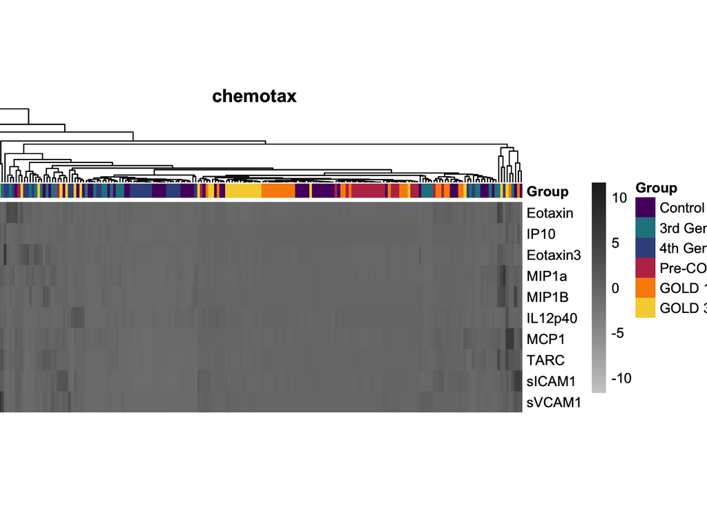

```r
individual_heatmap(md_combat, chemotax)
```

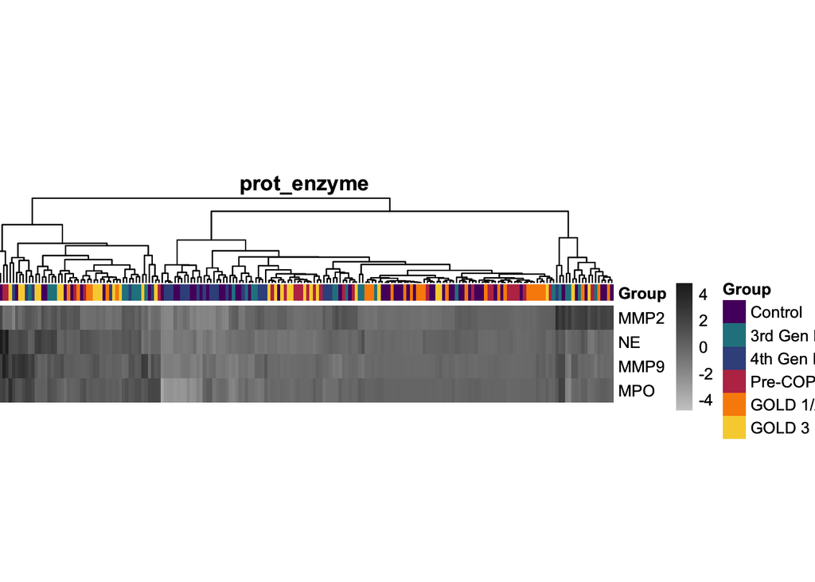

```r
individual_heatmap(md_combat, prot_enzyme)
```

```r
dev.off()
```

```r
# Write heatmaps out
pdf(file = "2_OutputFigs/Heatmap_ByBioSet_IndividualSubjects_immuno_inflamm.pdf",
    width = 10,
    height = 5)

individual_heatmap(md_combat, immuno_inflamm)

dev.off()
```

```r
pdf(file = "2_OutputFigs/Heatmap_ByBioSet_IndividualSubjects_chemotax.pdf",
    width = 10,
    height = 5)

individual_heatmap(md_combat, chemotax)

dev.off()
```

```r
pdf(file = "2_OutputFigs/Heatmap_ByBioSet_IndividualSubjects_prot_enzyme.pdf",
    width = 10,
    height = 5)

individual_heatmap(md_combat, prot_enzyme)

dev.off()
```

```r
# Make heatmap of all mediators
all_meds <- c(chemotax, immuno_inflamm, prot_enzyme)

pdf(file = "2_OutputFigs/Heatmap_ByBioSet_IndividualSubjects_all_meds.pdf",
    width = 10,
    height = 10)

individual_heatmap(md_combat, all_meds)

dev.off()
```

# 7 Mahalanobis distance to assess similarity between groups

The Mahalanobis distance can be used to determine similarity/dissimilarity between groups in the multivariate space.

```r
# How to install HDMD since it is archived:
# library(devtools)
# install_url('https://cran.r-project.org/src/contrib/Archive/HDMD/HDMD_1.2.tar.gz')
```

```r
# Make group ID
groups <- md_all %>%
  rownames_to_column("SubjectID") %>%
  dplyr::select(c(SubjectID, Group_2)) %>%
  rename("Group" = "Group_2")

# Set up data frame
# Set up data frame
md_combat_for_mahalo <- md_combat %>%
  right_join(groups, by = "SubjectID") %>%
  dplyr::select(-SubjectID)

# Prepare data to compare groups
group = matrix(md_combat_for_mahalo$Group)
group = t(group[,1])

# Variables being used for comparison
variables = names(md_combat %>% dplyr::select(-SubjectID))
variables = as.matrix(md_combat_for_mahalo[,variables])

# Get squared mahalanobis distances
mahala_sq <- pairwise.mahalanobis(x = variables, grouping = group)

# Capture labels
names = rownames(mahala_sq$means)

# Extract mahalanobis distnace
mahala = sqrt(mahala_sq$distance)

# Set row and column names in the dissimilarity matrix
rownames(mahala) = names
colnames(mahala) = names

# This is the mahalanobis dissimilarity matrix
datatable(mahala)
```

|  | 3rd Gen | 4th Gen | Control | GOLD 1/2 | GOLD 3 | Pre-COPD |
| --- | --- | --- | --- | --- | --- | --- |
| 3rd Gen | 0 | 547215.1047415624 | 661105.0222088303 | 695482.1531074266 | 433707.9112266059 | 426447.0000915666 |
| 4th Gen | 547215.1047415624 | 0 | 403265.5995078561 | 366295.7459643146 | 599024.0452406196 | 203926.8035008236 |
| Control | 661105.0222088303 | 403265.5995078561 | 0 | 85475.79806981617 | 909240.0231608329 | 504644.54282389 |
| GOLD 1/2 | 695482.1531074266 | 366295.7459643146 | 85475.79806981617 | 0 | 904551.2590814922 | 482652.6638488562 |
| GOLD 3 | 433707.9112266059 | 599024.0452406196 | 909240.0231608329 | 904551.2590814922 | 0 | 440636.6513240752 |
| Pre-COPD | 426447.0000915666 | 203926.8035008236 | 504644.54282389 | 482652.6638488562 | 440636.6513240752 | 0 |

```r
# Make a summary data frame
mahala_summary <- data.frame(var1 = rownames(mahala)[row(mahala)[upper.tri(mahala)]],
           var2 = colnames(mahala)[col(mahala)[upper.tri(mahala)]],
           mahala_dist = mahala[upper.tri(mahala)]) %>%
  rename("All Mediators" = "mahala_dist") %>%
  unite(var_pair, var1, var2, sep = "_")

# Write function for pairwise Mahalnobis distance with subset of mediators
mahalanobis_subset <- function(data, variable_list) {

  data <- data %>%
    dplyr::select(c(all_of(variable_list), Group))

  # Prepare data to compare groups
  group = matrix(data$Group)
  group = t(group[,1])

  # Variables being used for comparison
  variables = names(data %>% dplyr::select(-Group))
  variables = as.matrix(data[,variables])

  # Get squared mahalanobis distances
  mahala_sq <- pairwise.mahalanobis(x = variables, grouping = group)

  # Capture labels
  names = rownames(mahala_sq$means)

  # Extract mahalanobis distnace
  mahala = sqrt(mahala_sq$distance)

  # Set row and column names in the dissimilarity matrix
  rownames(mahala) = names
  colnames(mahala) = names

  # Extract results
  mahala_summary <- data.frame(var1 = rownames(mahala)[row(mahala)[upper.tri(mahala)]],
           var2 = colnames(mahala)[col(mahala)[upper.tri(mahala)]],
           mahala_dist = mahala[upper.tri(mahala)]) %>%
    unite(var_pair, var1, var2, sep = "_")

  mahala_summary
}

mahala_immuno <- mahalanobis_subset(md_combat_for_mahalo, immuno_inflamm) %>% rename("Inflamm" = "mahala_dist")
mahala_chemotax <- mahalanobis_subset(md_combat_for_mahalo, chemotax) %>% rename("Chemotax" = "mahala_dist")
mahala_prot <- mahalanobis_subset(md_combat_for_mahalo, prot_enzyme) %>% rename("Prot/Enz" = "mahala_dist")

# Make group lists
ecig_groups <- c("3rd Gen", "4th Gen")
copd_groups <- c("Pre-COPD", "GOLD 1/2", "GOLD 3")
control <- c("Control")

# Join together data frames and add grouping
mahala_all <- list(mahala_summary, mahala_immuno, mahala_chemotax, mahala_prot) %>%
  reduce(full_join, by = "var_pair") %>%
  separate(var_pair, into = c("var1", "var2"), remove = FALSE, sep = "_") %>%
  mutate(type = ifelse(var1 %in% ecig_groups & var2 %in% ecig_groups, "Within Ecig",
                       ifelse(var1 %in% ecig_groups & var2 == "Control", "To Ctrl",
                              ifelse(var1 %in% ecig_groups & var2 %in% copd_groups |
                                       var1 %in% copd_groups & var2 %in% ecig_groups, "Ecig COPD",
                                     ifelse(var1 == "Control" & var2 %in% copd_groups, "To Ctrl", "Within COPD"))))) %>%
  mutate(type = recode(type, "Within COPD" = "1", "Within Ecig" = "2", "To Ctrl" = "3", "Ecig COPD" = "4")) %>%
  arrange(type)

# Add in index column and find where to add breaks in heat map to separate clusters
mahala_all$index <- 1:nrow(mahala_all)
hm_breaks <- mahala_all %>% group_by(type) %>% summarise(m=max(index))
```

Distances from 4th Gen e-cig users:

```r
minmax <- function(x, na.rm = TRUE) {
    return((x- min(x)) /(max(x)-min(x)))
}

mahala_all_minmax <- mahala_all %>%
  mutate(across(`All Mediators`:`Prot/Enz`, ~ 1/.x)) %>%
  mutate(across(`All Mediators`:`Prot/Enz`, minmax))

mahala_all_4thgen <- mahala_all_minmax %>%
  filter(var1 == "4th Gen" | var2 == "4th Gen") %>%
  mutate(var_pair = gsub("4th Gen", "", var_pair)) %>%
  mutate(var_pair = gsub("_", "", var_pair)) %>%
  dplyr::select(c(var_pair, `All Mediators`:`Prot/Enz`)) %>%
  pivot_longer(!var_pair, names_to = "variable", values_to = "value") %>%
  mutate(value = round(value, digits = 3))

row_df <- data.frame(var_pair = c("Control", "3rd Gen", "Pre-COPD", "GOLD 1/2", "GOLD 3"), row = c(5, 4, 3, 2, 1))
col_df <- data.frame(variable = c("All Mediators", "Inflamm", "Chemotax", "Prot/Enz"), col = c(1, 2, 3, 4))

mahala_all_4thgen <- mahala_all_4thgen %>%
  left_join(row_df, by = "var_pair") %>%
  left_join(col_df, by = "variable")

mahala_all_4thgen %>% arrange(row)
```

```
## # A tibble: 20 × 5
##    var_pair variable      value   row   col
##    <chr>    <chr>         <dbl> <dbl> <dbl>
##  1 GOLD 3   All Mediators 0.054     1     1
##  2 GOLD 3   Inflamm       0.01      1     2
##  3 GOLD 3   Chemotax      0         1     3
##  4 GOLD 3   Prot/Enz      0.053     1     4
##  5 GOLD 1/2 All Mediators 0.154     2     1
##  6 GOLD 1/2 Inflamm       0.082     2     2
##  7 GOLD 1/2 Chemotax      0.001     2     3
##  8 GOLD 1/2 Prot/Enz      0.21      2     4
##  9 Pre-COPD All Mediators 0.359     3     1
## 10 Pre-COPD Inflamm       0.073     3     2
## 11 Pre-COPD Chemotax      0.001     3     3
## 12 Pre-COPD Prot/Enz      0.541     3     4
## 13 3rd Gen  All Mediators 0.069     4     1
## 14 3rd Gen  Inflamm       0.155     4     2
## 15 3rd Gen  Chemotax      0.013     4     3
## 16 3rd Gen  Prot/Enz      0.034     4     4
## 17 Control  All Mediators 0.13      5     1
## 18 Control  Inflamm       0.044     5     2
## 19 Control  Chemotax      0.004     5     3
## 20 Control  Prot/Enz      0.195     5     4
```

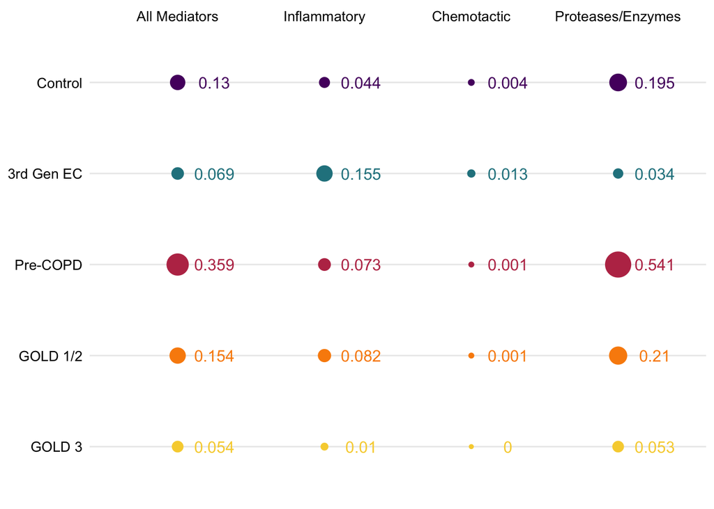

```r
vars_x_axis <- c("All Mediators", "Inflammatory", "Chemotactic", "Proteases/Enzymes")
vars_y_axis <- c("GOLD 3", "GOLD 1/2", "Pre-COPD", "3rd Gen EC", "Control")

baloonplot_4thgen <- ggplot(mahala_all_4thgen, aes(x=factor(col), y=factor(row), color=var_pair, size=value)) +
  scale_color_manual(values = rev(c("#BB3754FF", "#f7d13d", "#F98C0AFF", "#56106EFF", "#26828e"))) +
  geom_point() +    # plot as points
  geom_text(aes(label=value, x=col + 0.25), size=4) +   # display the value next to the "balloons"
  scale_size(range = c(1, 8)) +
  scale_x_discrete(breaks=1:length(vars_x_axis), labels=vars_x_axis, position='top') +
  scale_y_discrete(breaks=1:length(vars_y_axis), labels=vars_y_axis) +
  theme_bw() +
  theme(axis.line = element_blank(),
        axis.title = element_blank(),
        panel.border = element_blank(),
        panel.grid.major.x = element_blank(),
        panel.grid.minor.x = element_blank(),
        legend.position = "none",
        axis.text = element_text(size = 10, color = "black"),
        axis.ticks = element_blank())

pdf("2_OutputFigs/Balloonplot_4thgen_log.pdf", height = 2, width = 7)
baloonplot_4thgen
invisible(dev.off())

baloonplot_4thgen
```

```r
mahala_all_3rdgen <- mahala_all_minmax %>%
  filter(var1 == "3rd Gen" | var2 == "3rd Gen") %>%
  mutate(var_pair = gsub("3rd Gen", "", var_pair)) %>%
  mutate(var_pair = gsub("_", "", var_pair)) %>%
  dplyr::select(c(var_pair, `All Mediators`:`Prot/Enz`)) %>%
  pivot_longer(!var_pair, names_to = "variable", values_to = "value") %>%
  mutate(value = round(value, digits = 3))

row_df <- data.frame(var_pair = c("Control", "4th Gen", "Pre-COPD", "GOLD 1/2", "GOLD 3"), row = c(5, 4, 3, 2, 1))
col_df <- data.frame(variable = c("All Mediators", "Inflamm", "Chemotax", "Prot/Enz"), col = c(1, 2, 3, 4))

mahala_all_3rdgen <- mahala_all_3rdgen %>%
  left_join(row_df, by = "var_pair") %>%
  left_join(col_df, by = "variable")

mahala_all_3rdgen %>% arrange(row)
```

```
## # A tibble: 20 × 5
##    var_pair variable      value   row   col
##    <chr>    <chr>         <dbl> <dbl> <dbl>
##  1 GOLD 3   All Mediators 0.114     1     1
##  2 GOLD 3   Inflamm       0.007     1     2
##  3 GOLD 3   Chemotax      0.026     1     3
##  4 GOLD 3   Prot/Enz      0.182     1     4
##  5 GOLD 1/2 All Mediators 0.032     2     1
##  6 GOLD 1/2 Inflamm       0.183     2     2
##  7 GOLD 1/2 Chemotax      0.031     2     3
##  8 GOLD 1/2 Prot/Enz      0.007     2     4
##  9 Pre-COPD All Mediators 0.117     3     1
## 10 Pre-COPD Inflamm       0.169     3     2
## 11 Pre-COPD Chemotax      0.031     3     3
## 12 Pre-COPD Prot/Enz      0.076     3     4
## 13 4th Gen  All Mediators 0.069     4     1
## 14 4th Gen  Inflamm       0.155     4     2
## 15 4th Gen  Chemotax      0.013     4     3
## 16 4th Gen  Prot/Enz      0.034     4     4
## 17 Control  All Mediators 0.039     5     1
## 18 Control  Inflamm       0.103     5     2
## 19 Control  Chemotax      0.062     5     3
## 20 Control  Prot/Enz      0.02      5     4
```

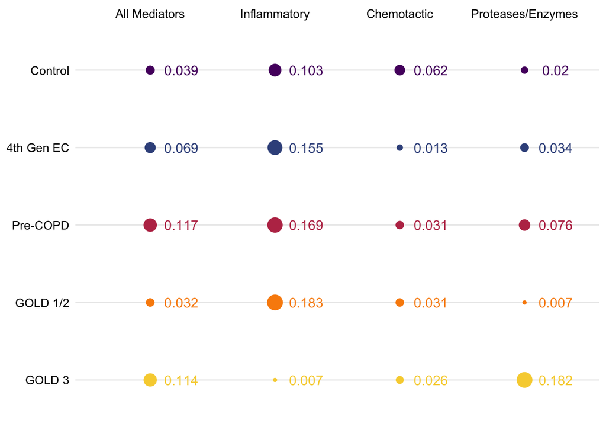

```r
vars_x_axis <- c("All Mediators", "Inflammatory", "Chemotactic", "Proteases/Enzymes")
vars_y_axis <- c("GOLD 3", "GOLD 1/2", "Pre-COPD", "4th Gen EC", "Control")

baloonplot_3rdgen <- ggplot(mahala_all_3rdgen, aes(x=factor(col), y=factor(row), color=var_pair, size=value)) +
  scale_color_manual(values = rev(c("#BB3754FF","#f7d13d" , "#F98C0AFF", "#56106EFF", "#3b528b"))) +
  geom_point() +    # plot as points
  geom_text(aes(label=value, x=col + 0.25), size=4) +   # display the value next to the "balloons"
  scale_size(range = c(1, 5.5)) +
  scale_x_discrete(breaks=1:length(vars_x_axis), labels=vars_x_axis, position='top') +
  scale_y_discrete(breaks=1:length(vars_y_axis), labels=vars_y_axis) +
  theme_bw() +
  theme(axis.line = element_blank(),
        axis.title = element_blank(),
        panel.border = element_blank(),
        panel.grid.major.x = element_blank(),
        panel.grid.minor.x = element_blank(),
        legend.position = "none",
        axis.text = element_text(size = 10, color = "black"),
        axis.ticks = element_blank())

pdf("2_OutputFigs/Balloonplot_3rdgen_log.pdf", height = 2, width = 7)
baloonplot_3rdgen
invisible(dev.off())

baloonplot_3rdgen
```

# 8 Write out table of results

```r
mahala_all_for_man <- mahala_all %>%
  arrange(desc(var2)) %>%
  arrange(desc(var1)) %>%
  dplyr::select(-c(type:index))

mahala_all_for_man_sim <- mahala_all_minmax %>%
  arrange(desc(var2)) %>%
  arrange(desc(var1)) %>%
  dplyr::select(-c(var1:var2, type:index)) %>%
  rename_with(.fn = ~paste0("sim_", .x), .cols = c('All Mediators':'Prot/Enz'))

mahala_table <- left_join(mahala_all_for_man, mahala_all_for_man_sim, by = "var_pair") %>%
  dplyr::select(-var_pair) %>%
  rename("Group 1" = "var1", "Group 2" = "var2")

write.xlsx(mahala_table, file = "3_OutputTables/MahalanobisDistAndSim.xlsx")
```